# 10_Emission_Analysis

2025-09-26

## Introduction

This notebook provides the analytical workflow used to quantify how observed **diet shifts** alter **enteric methane (CH₄) emission intensity (EI)** across **cattle, sheep, and goats** within African livestock systems.  
The analyses draw on the **ERA v1.0.1** georeferenced meta-dataset, which compiles more than 500 feeding trials conducted from 1934 to 2024 across the continent. The overarching objective is to link **diet composition**, **feed intake**, and **animal performance** with **Tier-2–based CH₄ emission estimates**, and to identify feeding practices that consistently reduce emission intensity while maintaining or improving productivity.

The workflow harmonizes heterogeneous datasets through a reproducible multi-stage pipeline that integrates:

- **Gross energy (GE) reconstruction:** a five-step cascade combining ERA records, Feedipedia tabulated values, ILRI feed composition libraries, and the Weiss & Tebbe (2019) empirical equation.
- **Methane estimation:** application of the **IPCC Tier-2** approach to derive daily CH₄ emissions (g CH₄ animal⁻¹ day⁻¹) from reconstructed GE intake and species-specific methane conversion factors (Ym).
- **Emission intensity (EI) computation:** CH₄ emissions expressed per unit of animal output (milk or meat) standardized to daily or annual scales.
- **Practice classification:** experimental diets categorized as *Additions*, *Substitutions*, or *No change* based on proportional changes in ingredient-level dry-matter shares.
- **Ingredient functional grouping:** feeds harmonized into six categories—high-starch, high-fat, protein, good forage, poor forage, and mineral/vitamin supplements—validated by livestock nutrition experts.

All figures and summary tables produced here are intended to support manuscript preparation, enabling co-authors to review data coverage, classification logic, and reproducible emission-intensity metrics generated from the harmonized dataset.

## Primary data exploration

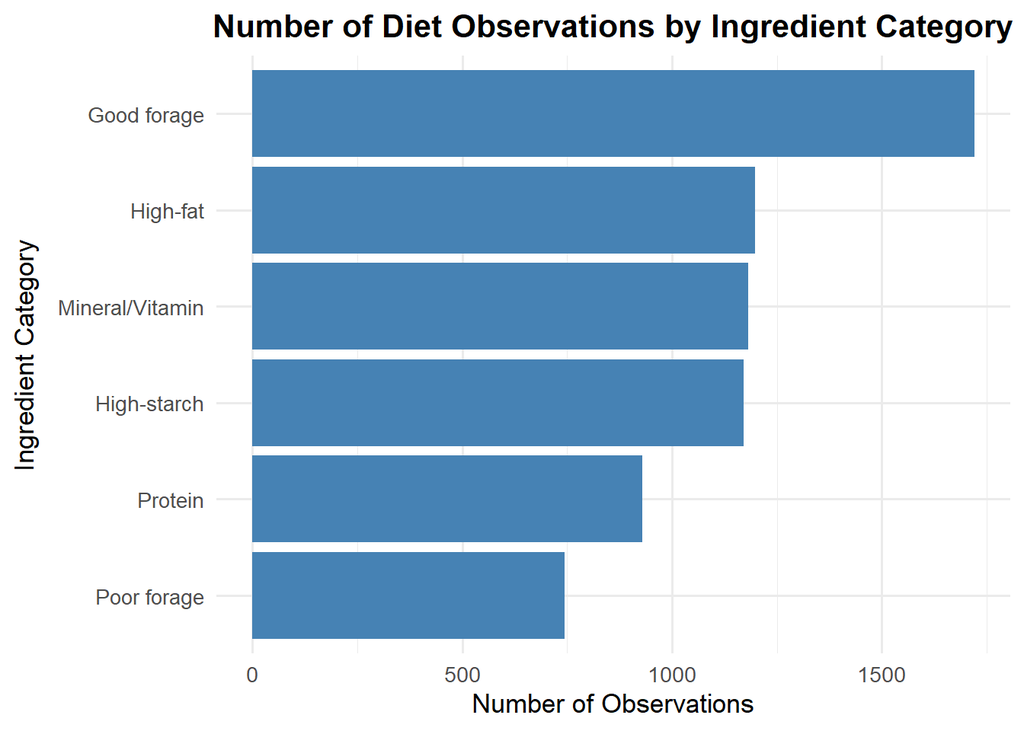

[figure not shown]

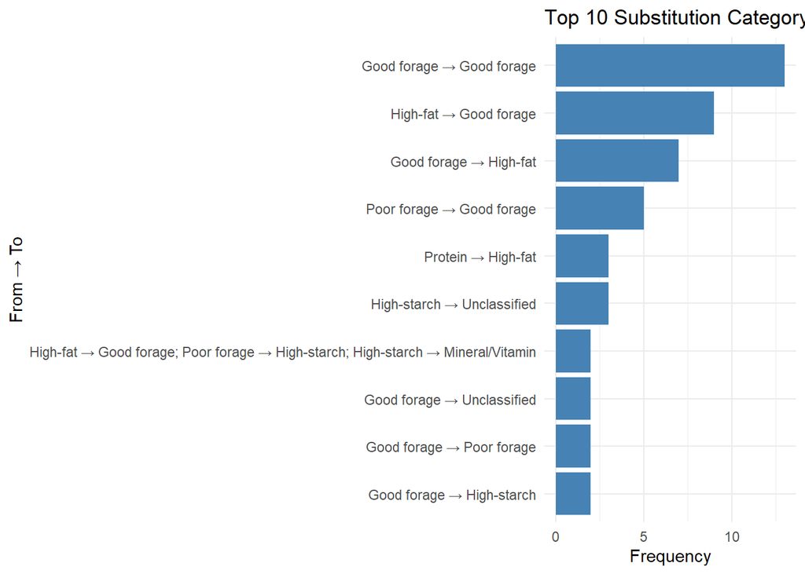

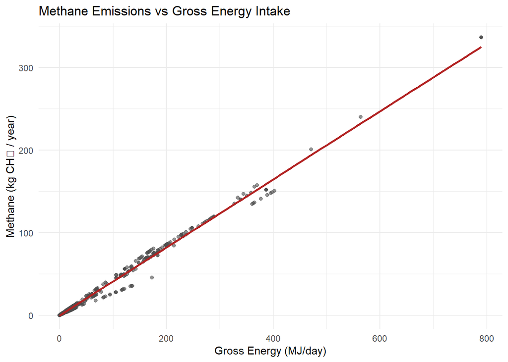

## Emission in function of the highest cat in each diet

```
## # A tibble: 17 × 6
## # Groups:   P.Product [3]
##    P.Product dom_category    n_diets mean_CH4 median_CH4 sd_CH4
##    <chr>     <chr>             <int>    <dbl>      <dbl>  <dbl>
##  1 Cattle    Good forage          61    59.4       64.8  37.0
##  2 Cattle    High-starch          35    77.0       70.5  51.6
##  3 Cattle    High-fat             18    77.7       63.9  77.2
##  4 Cattle    Poor forage          17    34.2       39.7  18.6
##  5 Cattle    Protein               6    67.9       66.8  25.9
##  6 Goat      Good forage         127     5.48       3.35  8.89
##  7 Goat      Poor forage          55     5.78       3.19 11.9
##  8 Goat      High-fat             39     5.13       4.54  3.67
##  9 Goat      High-starch          26     4.17       2.65  3.48
## 10 Goat      Protein               9     1.87       1.43  0.863
## 11 Goat      Mineral/Vitamin       5     2.50       0     3.43
## 12 Sheep     Good forage         147     5.83       5.61  2.68
## 13 Sheep     Poor forage          86     5.41       4.65  8.75
## 14 Sheep     High-fat             65     6.31       6.32  2.49
## 15 Sheep     High-starch          58     6.89       6.59  2.93
## 16 Sheep     Protein              20     6.72       6.35  3.05
## 17 Sheep     Mineral/Vitamin       2     1.80       1.80  2.54
```

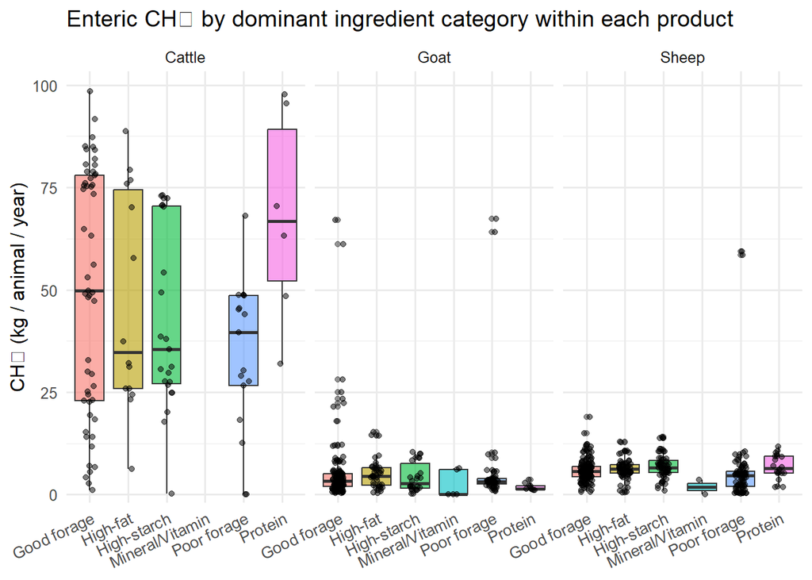

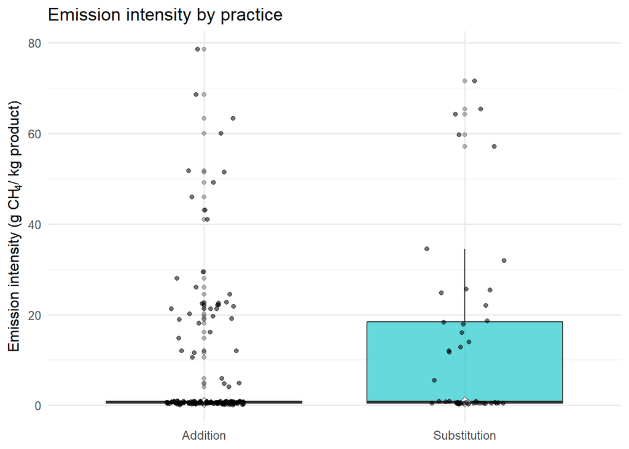

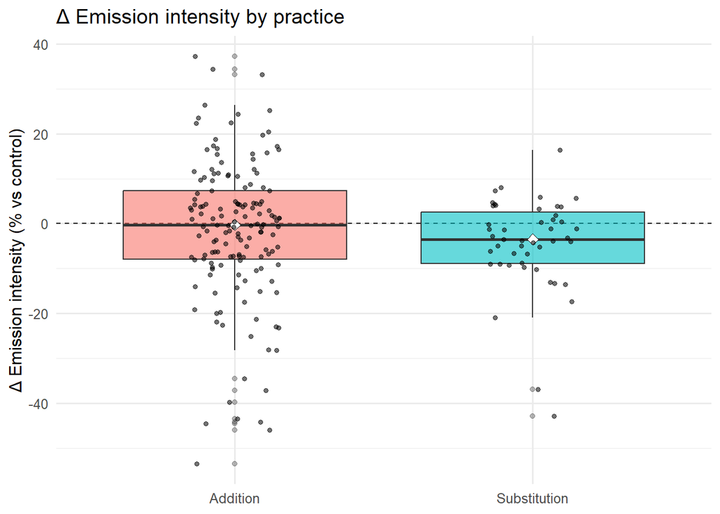

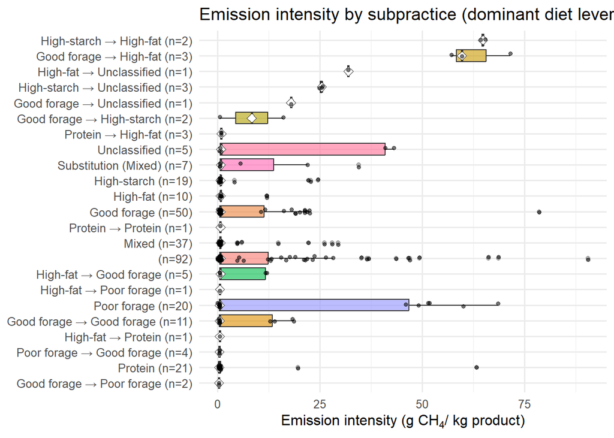

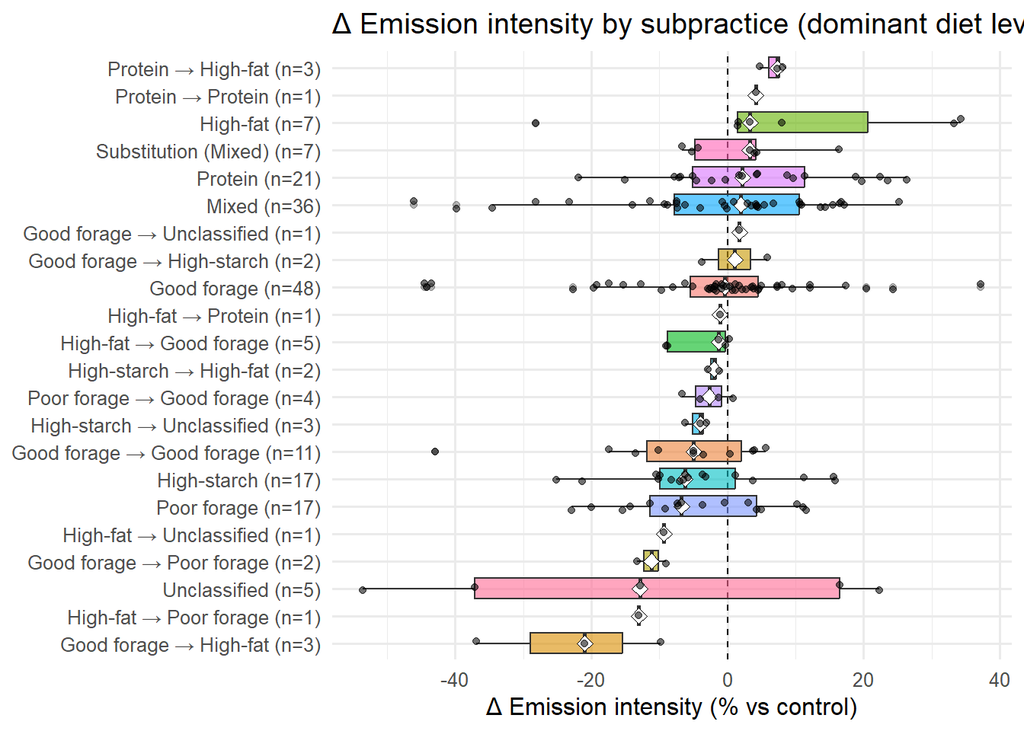

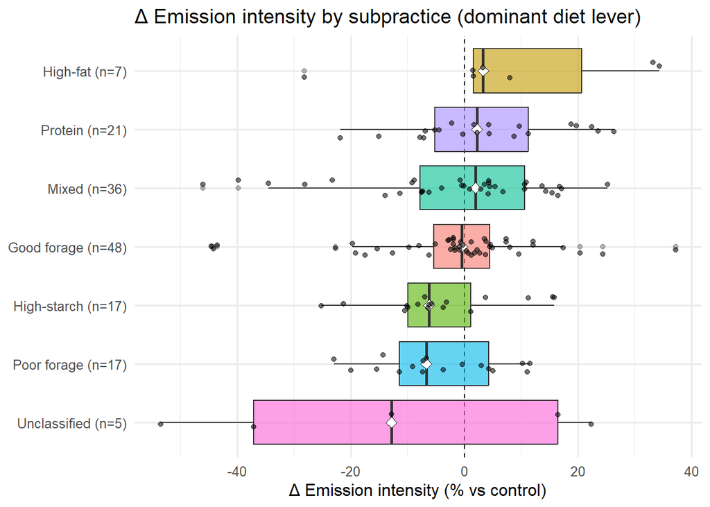

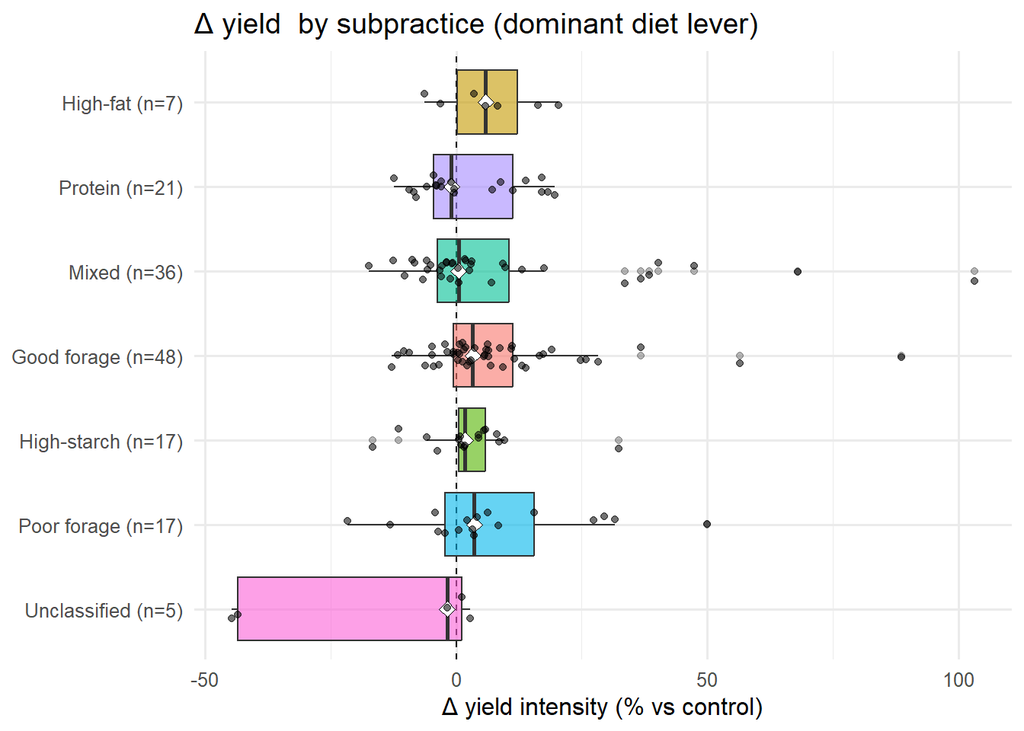

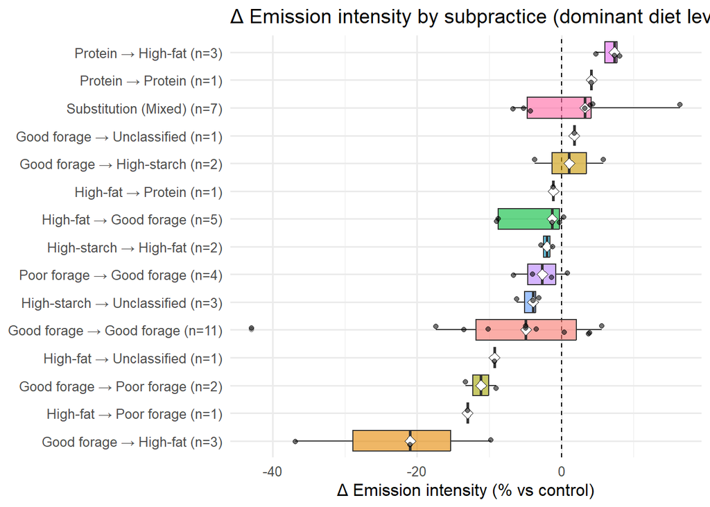

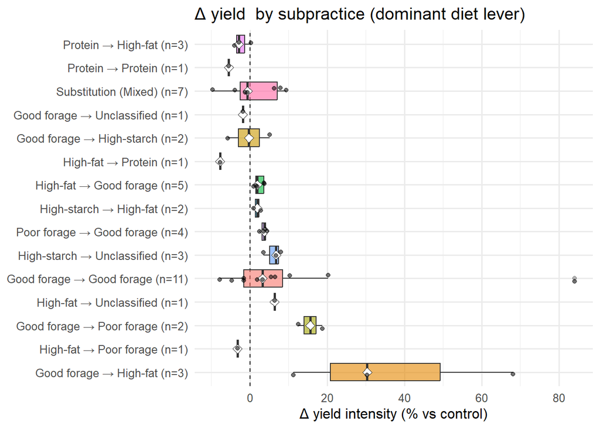

[output not shown]

##map

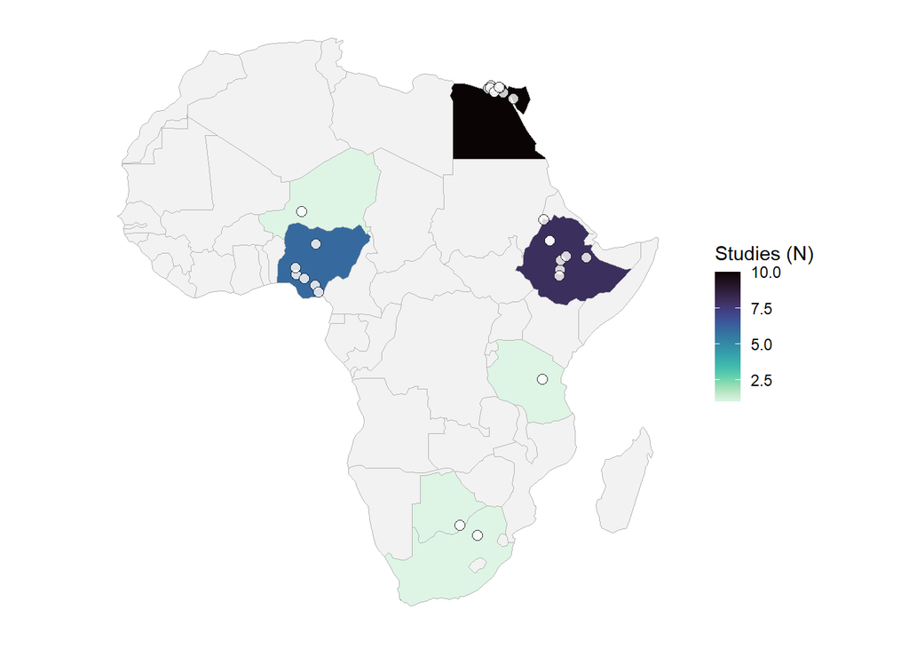

## separating small and big ruminants

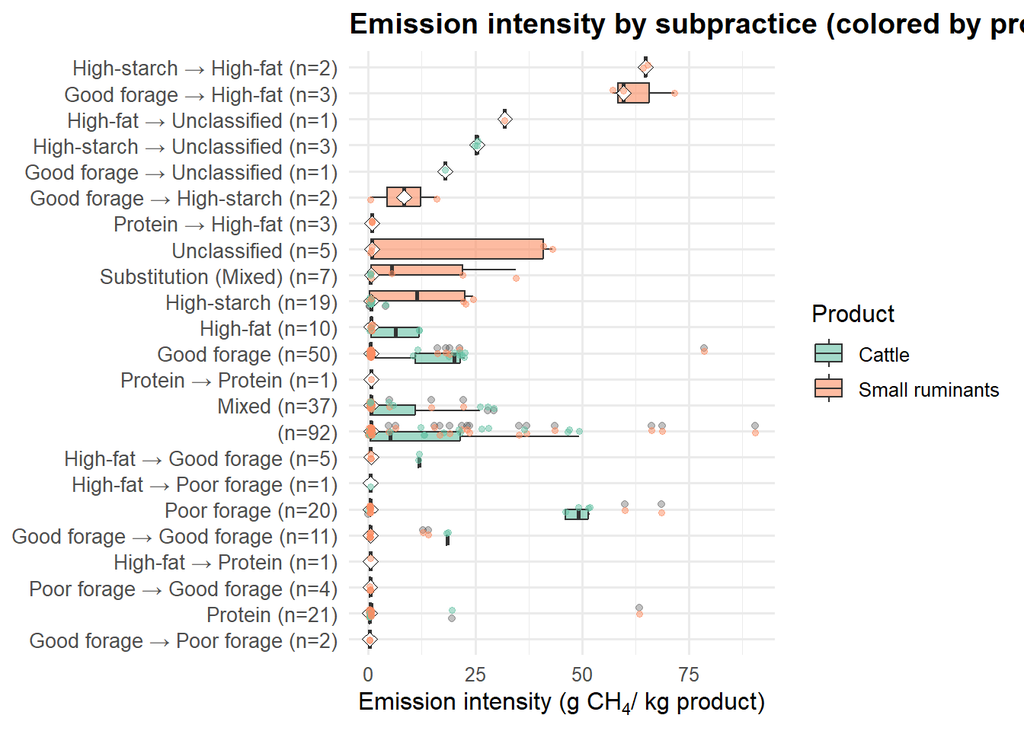

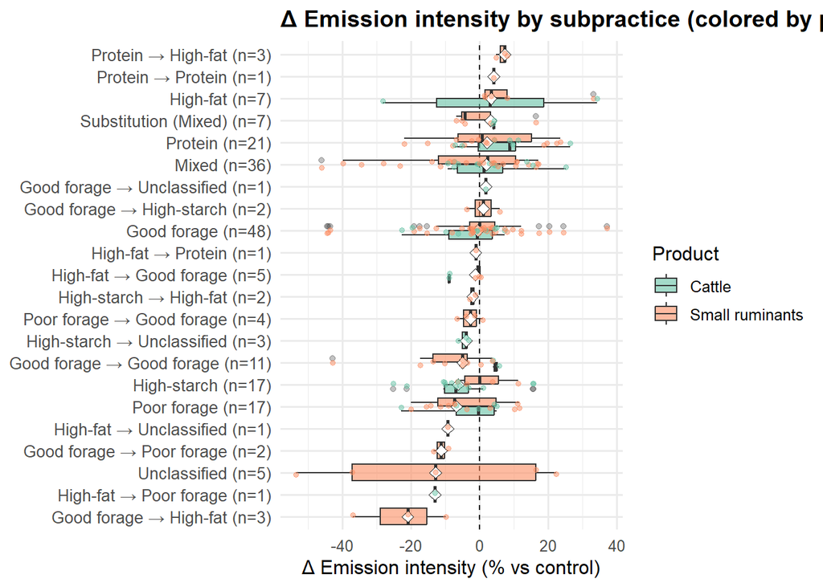

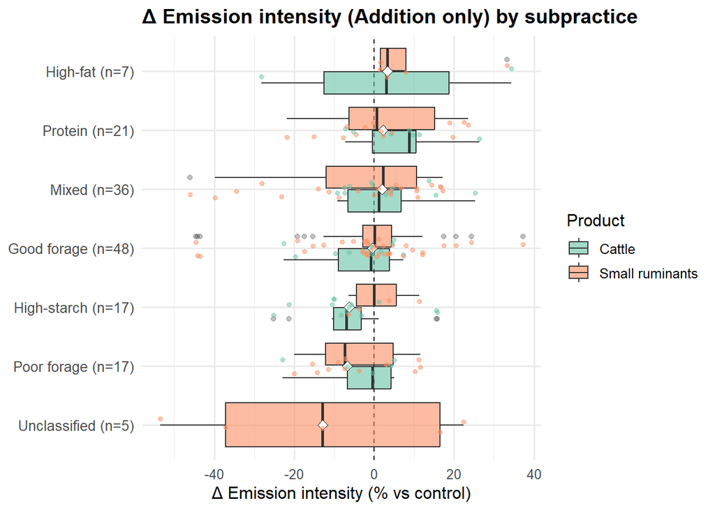

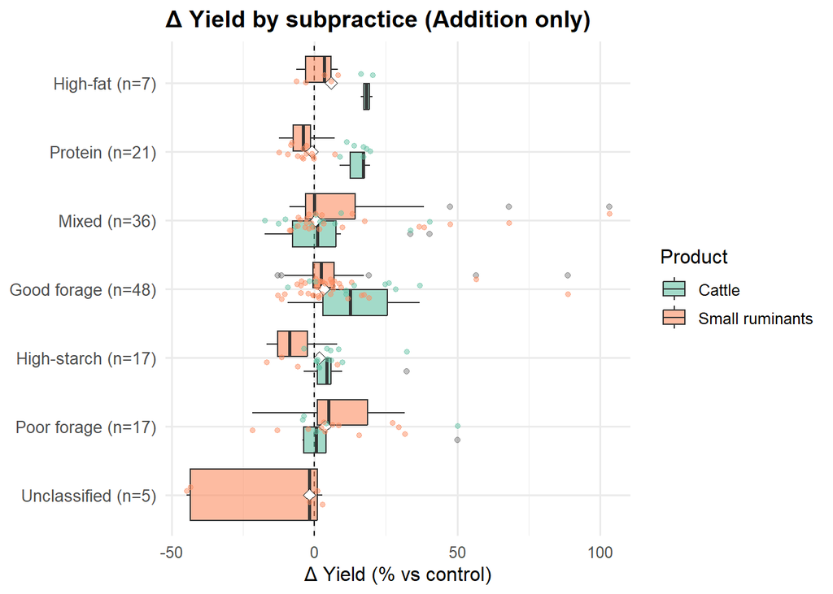

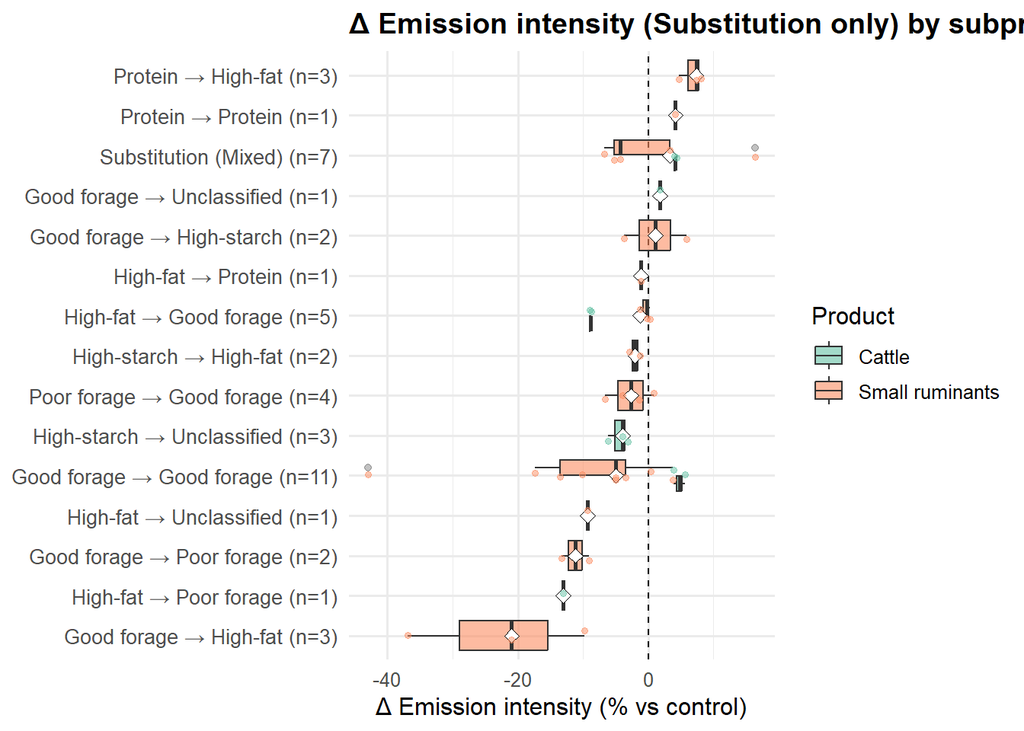

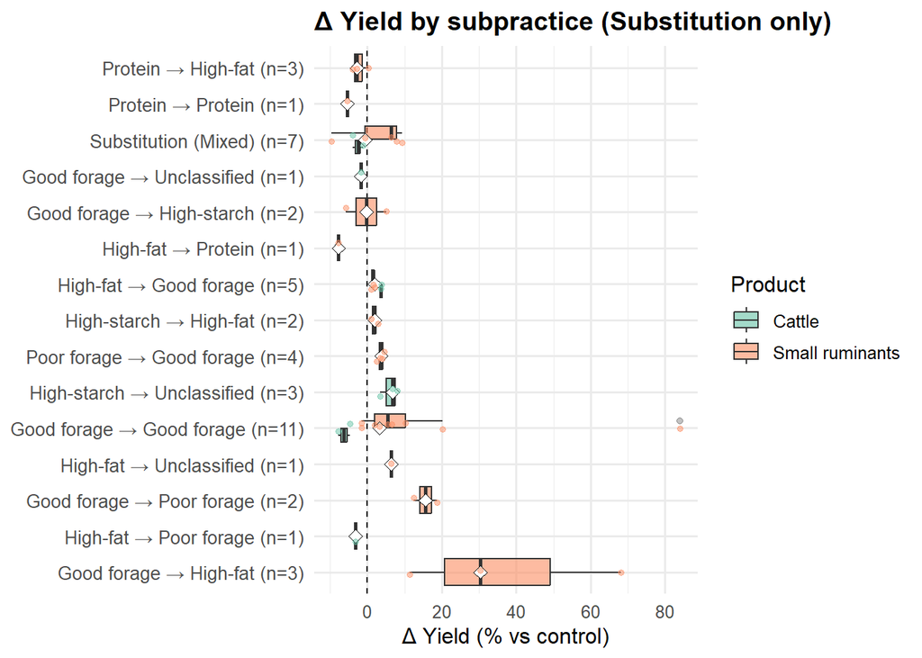

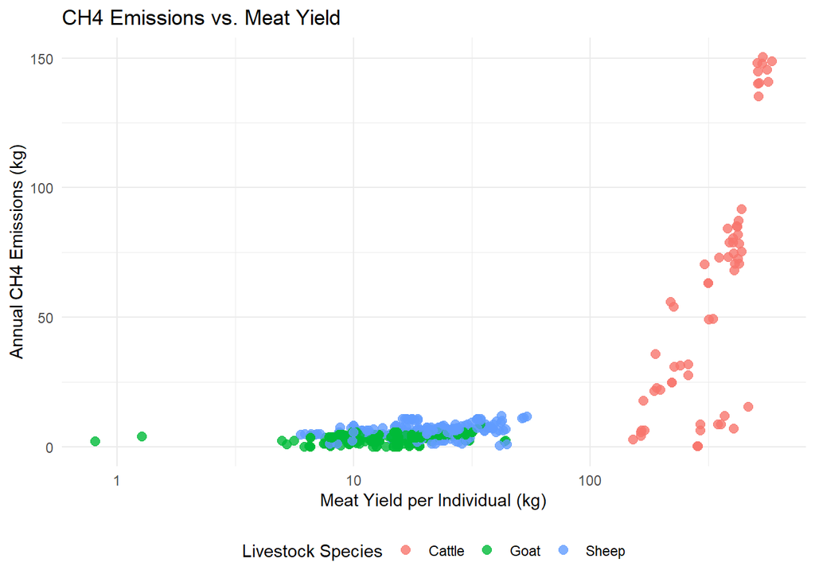

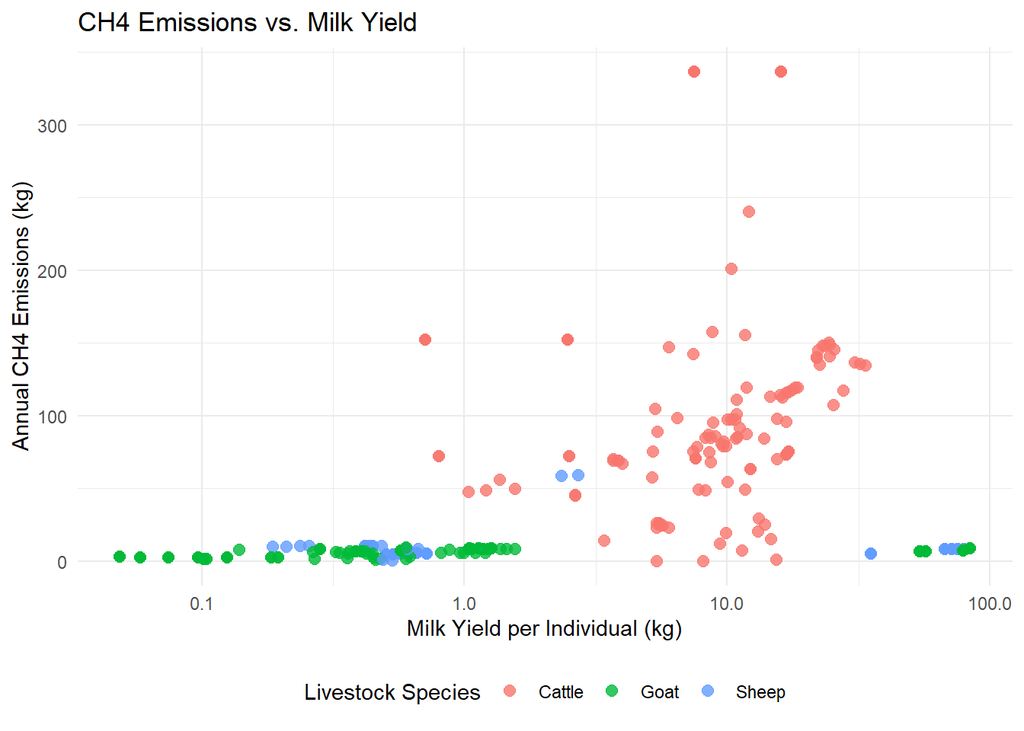

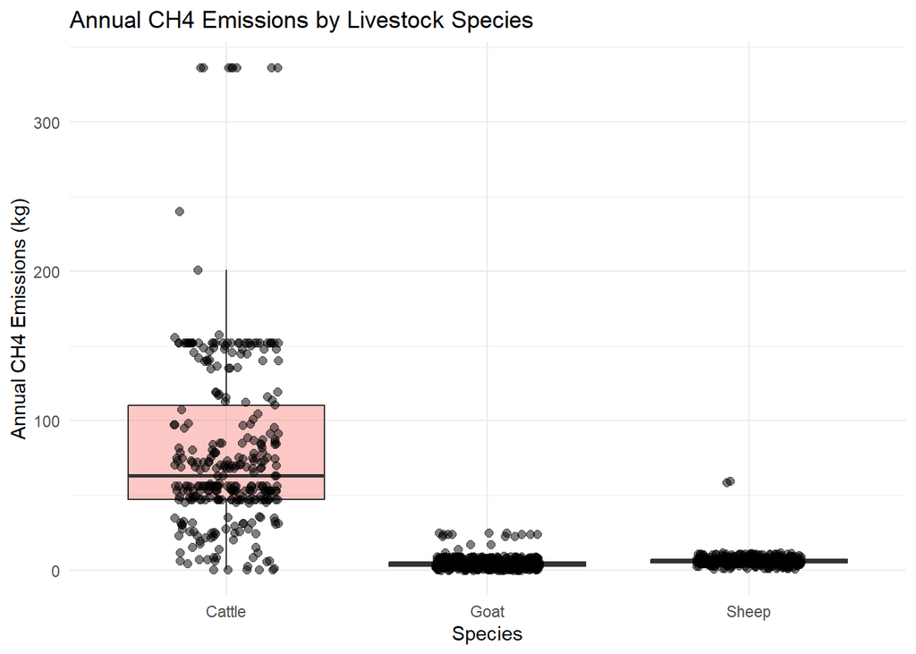

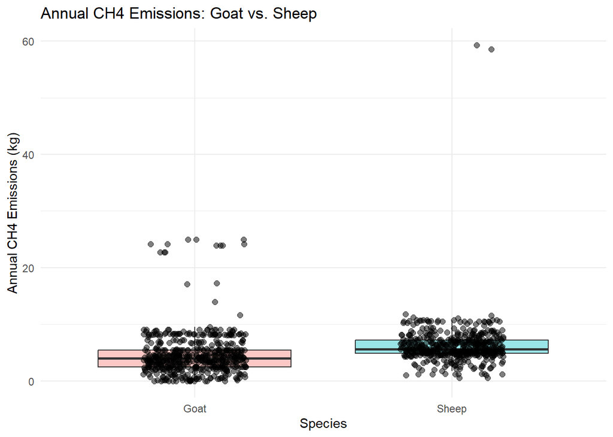

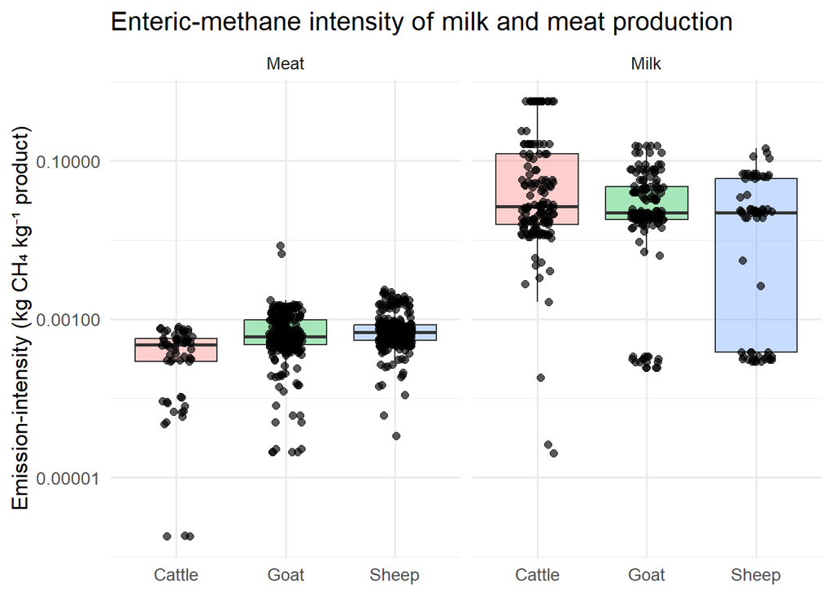

## diet shift analysis

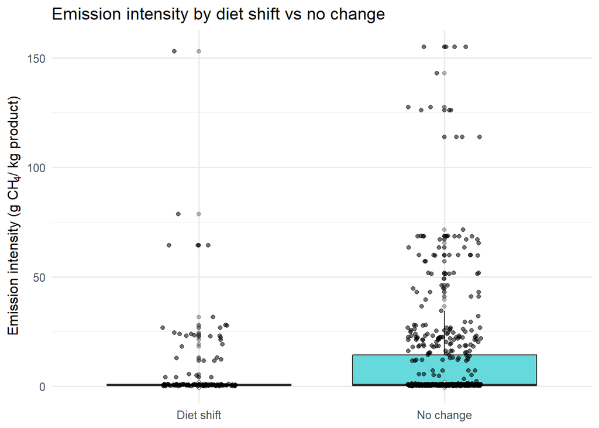

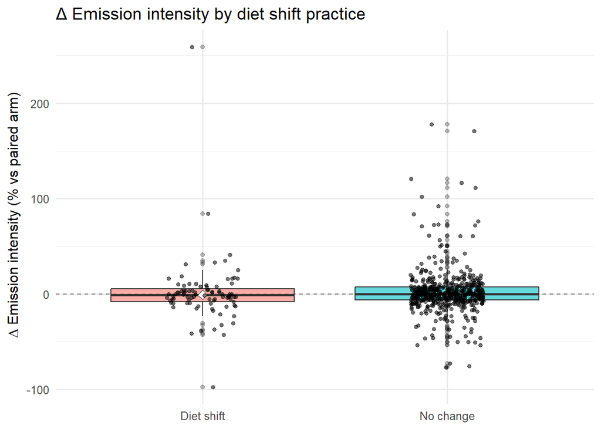

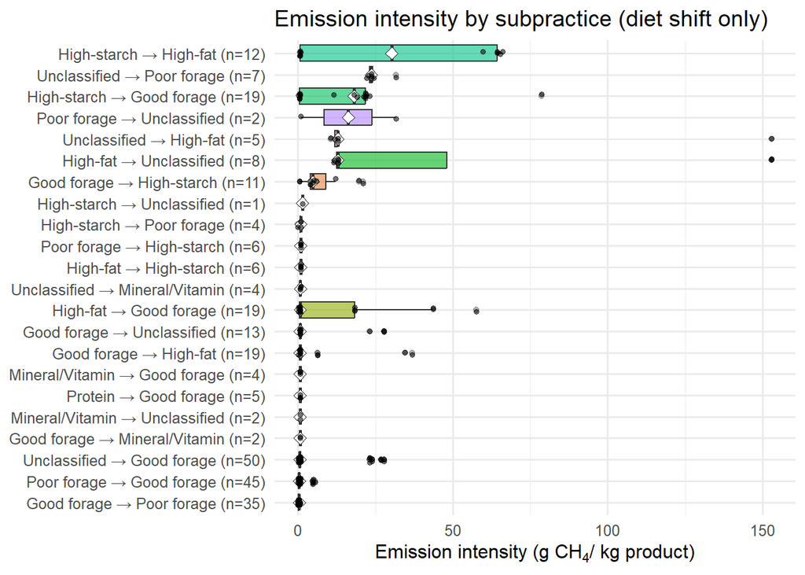

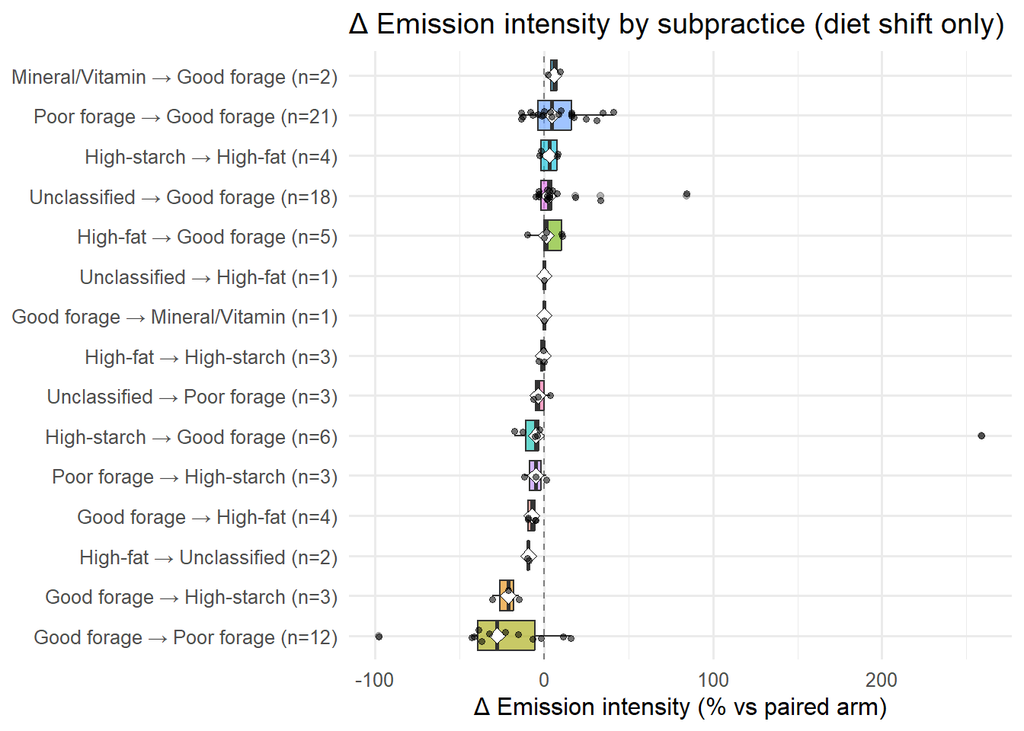

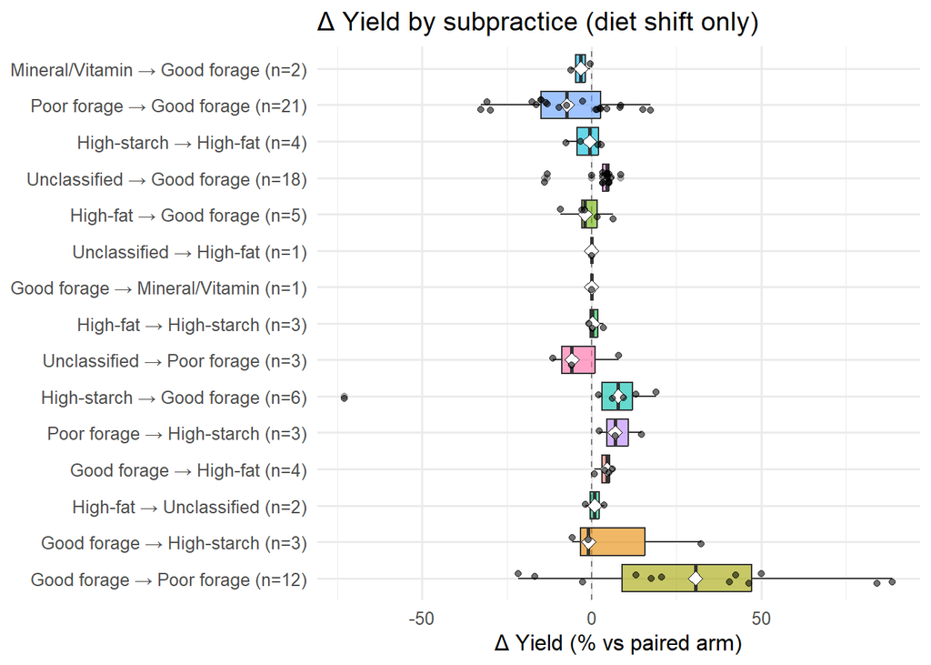

## number of papers